# Group members:

16520399 Nguyen Minh Hieu  
16521574 Nguyen Minh Quan

# Assignment Part 2

```python
import re
import pandas as pd
import numpy as np
import seaborn as sns
from sklearn import preprocessing
import matplotlib.pyplot as plt
#load the cleaned data
df = pd.read_csv("clean_data.csv")
df
```

|  | Title | Company | Date | Location | Area | Classification | SubClassification | Requirement | FullDescription | LowestSalary | HighestSalary | JobType |
| --- | --- | --- | --- | --- | --- | --- | --- | --- | --- | --- | --- | --- |
| 0 | Casual Stock Replenisher | Aldi Stores | 2018-10-07 | Sydney | North West & Hills District | Retail & Consumer Products | Retail Assistants | Our Casual Stock Replenishers pride themselves... | NaN | 0 | 30 | NaN |
| 1 | Casual Stock Replenisher | Aldi Stores | 2018-10-07 | Richmond & Hawkesbury | NaN | Retail & Consumer Products | Retail Assistants | Our Casual Stock Replenishers pride themselves... | NaN | 0 | 30 | NaN |
| 2 | RETAIL SALES SUPERSTARS and STYLISTS Wanted - ... | LB Creative Pty Ltd | 2018-10-07 | Brisbane | CBD & Inner Suburbs | Retail & Consumer Products | Retail Assistants | BRAND NEW FLAGSHIP STORE OPENING - SUNSHINE PLAZA | NaN | 0 | 30 | NaN |
| 3 | Team member - Belrose | Anaconda Group Pty Ltd | 2018-10-07 | Gosford & Central Coast | NaN | Retail & Consumer Products | Retail Assistants | Bring it on - do you love the great outdoors a... | NaN | 0 | 30 | NaN |
| 4 | Business Banking Contact Centre Specialist, Ni... | Commonwealth Bank - Business & Private Banking | 2018-10-07 | Sydney | Ryde & Macquarie Park | Call Centre & Customer Service | Sales - Inbound | We are seeking highly articulate, enthusiastic... | NaN | 0 | 30 | NaN |
| ... | ... | ... | ... | ... | ... | ... | ... | ... | ... | ... | ... | ... |
| 318472 | Program Manager - Trade Reporting | Talenza | 2019-03-13 | NaN | NaN | NaN | NaN | Our client is a large Financial Services firm ... | NaN | 200 | 999 | NaN |
| 318473 | Web Content Writer - June 2019 contract | Talent – Winner ‘Seek Large Recruitment Agency... | 2019-03-13 | NaN | NaN | NaN | NaN | You will be able to write clearly and concisel... | NaN | 200 | 999 | NaN |
| 318474 | Brand Director - Global Premium Brand | Retail Career Consulting Pty Ltd | 2019-03-12 | NaN | NaN | NaN | NaN | Newly created Brand Director AUS. Must be comm... | NaN | 200 | 999 | NaN |
| 318475 | Head of Financial Planning, Reporting & Strategy | Moir Group | 2019-03-08 | NaN | NaN | NaN | NaN | High-quality manufacturing organisation. Excit... | NaN | 200 | 999 | NaN |
| 318476 | Head of Operations - EOI | Austcorp Executive | 2019-03-13 | NaN | NaN | NaN | NaN | Expressions of interest for a leadership role | NaN | 200 | 999 | NaN |

318477 rows × 12 columns

*Note: We will use the unormalized salary value so that the value can desribe the real salary which is easier to imagine.*

## 1) Study the job metadata. Extract the relevant information to describe the job’s attributes

### The sector and sub-sector of each job:

```python
# passing 3 columns Title, Classification, SubClassification, location, HighestSalary, LowestSalary to new table job
job = df[['Title', 'Classification', 'SubClassification', 'Location', 'HighestSalary', 'LowestSalary']]
# compute range of for each job and insert to job table
job['Range'] = job['HighestSalary'] - job['LowestSalary']
# change name of Classification to Sector and Subclassification to SubSector
job.rename(columns = {'Classification':'Sector', 'SubClassification':'SubSector'}, inplace = True)
job
```

|  | Title | Sector | SubSector | Location | HighestSalary | LowestSalary | Range |
| --- | --- | --- | --- | --- | --- | --- | --- |
| 0 | Casual Stock Replenisher | Retail & Consumer Products | Retail Assistants | Sydney | 30 | 0 | 30 |
| 1 | Casual Stock Replenisher | Retail & Consumer Products | Retail Assistants | Richmond & Hawkesbury | 30 | 0 | 30 |
| 2 | RETAIL SALES SUPERSTARS and STYLISTS Wanted - ... | Retail & Consumer Products | Retail Assistants | Brisbane | 30 | 0 | 30 |
| 3 | Team member - Belrose | Retail & Consumer Products | Retail Assistants | Gosford & Central Coast | 30 | 0 | 30 |
| 4 | Business Banking Contact Centre Specialist, Ni... | Call Centre & Customer Service | Sales - Inbound | Sydney | 30 | 0 | 30 |
| ... | ... | ... | ... | ... | ... | ... | ... |
| 318472 | Program Manager - Trade Reporting | NaN | NaN | NaN | 999 | 200 | 799 |
| 318473 | Web Content Writer - June 2019 contract | NaN | NaN | NaN | 999 | 200 | 799 |
| 318474 | Brand Director - Global Premium Brand | NaN | NaN | NaN | 999 | 200 | 799 |
| 318475 | Head of Financial Planning, Reporting & Strategy | NaN | NaN | NaN | 999 | 200 | 799 |
| 318476 | Head of Operations - EOI | NaN | NaN | NaN | 999 | 200 | 799 |

318477 rows × 7 columns

```python
job['Sector'] = job['Sector'].fillna('')
job['SubSector'] = job['SubSector'].fillna('')
```

```python
job.groupby(['Title'])['Sector'].apply(', '.join).reset_index()
job.groupby(['Title'])['SubSector'].apply(', '.join).reset_index()
```

|  | Title | SubSector |
| --- | --- | --- |
| 0 | Labo... |  |
| 1 | General Entry Meat Process Worker - Hemmant | Warehousing, Storage & Distribution |
| 2 | BRING IN THE NEW YEAR WITH A NEW CAREER- 10 ... |  |
| 3 | Data Integration Consultants - Dell Boomi Ex... |  |
| 4 | NEW YEAR, NEW CAREER- 10 X MANAGEMENT ROLES ... |  |
| ... | ... | ... |
| 168048 | \| Internal Sales Support/Stores \| Technical \| ... | , |
| 168049 | \| Mobilisation Co-ordinators \| Administration ... |  |
| 168050 | \| Technical Business Analyst \| Compliance \| Ca... | Business/Systems Analysts |
| 168051 | \| Workplace Trainer and Assessor \| High-Risk \|... |  |
| 168052 | \|HSE Advisor FIFO 2:1\|Mining/Resources\|Safety... |  |

168053 rows × 2 columns

```python
job[['Title', 'Sector', 'SubSector']].drop_duplicates()
```

|  | Title | Sector | SubSector |
| --- | --- | --- | --- |
| 0 | Casual Stock Replenisher | Retail & Consumer Products | Retail Assistants |
| 2 | RETAIL SALES SUPERSTARS and STYLISTS Wanted - ... | Retail & Consumer Products | Retail Assistants |
| 3 | Team member - Belrose | Retail & Consumer Products | Retail Assistants |
| 4 | Business Banking Contact Centre Specialist, Ni... | Call Centre & Customer Service | Sales - Inbound |
| 5 | Business Banking Contact Centre Specialist, Ni... | Call Centre & Customer Service | Customer Service - Call Centre |
| ... | ... | ... | ... |
| 318470 | General Manager, Transformation (PMO) c$270,00... |  |  |
| 318472 | Program Manager - Trade Reporting |  |  |
| 318473 | Web Content Writer - June 2019 contract |  |  |
| 318474 | Brand Director - Global Premium Brand |  |  |
| 318476 | Head of Operations - EOI |  |  |

202146 rows × 3 columns

### The location of the job:

```python
job[['Title', 'Location']].drop_duplicates()
job['Location'] = job['Location'].fillna(' ')
```

```python
job.groupby(['Title'])['Location'].apply(', '.join).reset_index().sort_values(by=['Location'], ascending=False)
```

|  | Title | Location |
| --- | --- | --- |
| 42192 | Customer Service Officer - Port Pirie (SA) | Yorke Peninsula & Clare Valley, Yorke Peninsul... |
| 95498 | Mental Health Clinical Nurse | Yorke Peninsula & Clare Valley, Yorke Peninsul... |
| 113868 | Process Worker | Yorke Peninsula & Clare Valley, Melbourne, Mel... |
| 90568 | Maintenance Fitter | Yorke Peninsula & Clare Valley, Melbourne, Mel... |
| 147560 | Skilled Meat Workers | Yorke Peninsula & Clare Valley, Launceston & N... |
| ... | ... | ... |
| 86759 | Lecturers Required |  |
| 86747 | Lecturer/Senior Lecturer, Computer Science |  |
| 86743 | Lecturer/Senior Lecturer, Architecture (Design) |  |
| 86729 | Lecturer/Senior Lecturer - Construction Techno... |  |
| 168052 | \|HSE Advisor FIFO 2:1\|Mining/Resources\|Safety... |  |

168053 rows × 2 columns

## 2) Study the market by locations

### **The market size in each city**

```python
print('Number of cities: ', len(df['Location'].unique()))
```

```
Number of cities:  66
```

**Number of jobs by city:**

```python
df_JobByCity = df.groupby('Location')['Title'].count().sort_values(ascending=False)
df_JobByCity
```

```
Location
Sydney                                  60765
Melbourne                               46690
Brisbane                                21466
Perth                                   13198
Adelaide                                 6653
                                        ...
Yorke Peninsula & Clare Valley             96
Tumut, Snowy & Monaro                      86
Somerset & Lockyer                         65
Fleurieu Peninsula & Kangaroo Island       64
Central & South East TAS                   57
Name: Title, Length: 65, dtype: int64
```

We will draw a pie chart which contains 7 cities having the most number of jobs

```python
others_no_jobs = df_JobByCity[df_JobByCity < df_JobByCity[6]].sum()
```

```python
df_JobByCity = df_JobByCity[df_JobByCity >= df_JobByCity[6]]
df_JobByCity['others'] = others_no_jobs
df_JobByCity
```

```
Location
Sydney                          60765
Melbourne                       46690
Brisbane                        21466
Perth                           13198
Adelaide                         6653
ACT                              6250
Newcastle, Maitland & Hunter     3958
others                          38249
Name: Title, dtype: int64
```

```python
sum_df_jobycity = df_JobByCity.sum()
percent_df_JobByCity = df_JobByCity/sum_df_jobycity
percent_df_JobByCity.sort_values(ascending=False)
```

```
Location
Sydney                          0.308094
Melbourne                       0.236730
others                          0.193932
Brisbane                        0.108838
Perth                           0.066917
Adelaide                        0.033732
ACT                             0.031689
Newcastle, Maitland & Hunter    0.020068
Name: Title, dtype: float64
```

As can be seen from the above result, Sydney and Melbourne are 2 cities that have most number of jobs(30.8% for Sydney and 23.67% for Melbourne)

**Pie chart of job-by-city table**

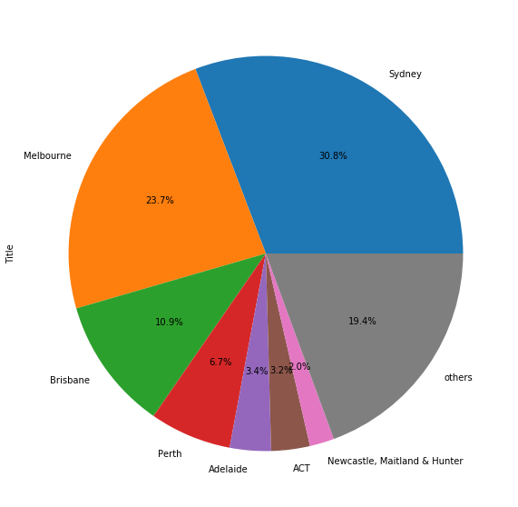

```python
plot = percent_df_JobByCity.plot.pie(y='', figsize=(10, 10), autopct='%1.1f%%')
```

Spatial Distribution of Jobs From Major Locations

```python
from adjustText import adjust_text
from mpl_toolkits.basemap import Basemap
from geopy.geocoders import Nominatim
from geopy.exc import GeocoderTimedOut
import matplotlib.pyplot as plt
```

```python
geolocator = Nominatim(user_agent='Big_Data_Assignment')
geolocator.geocode('Australia')
def geocode_no_timeout(address):
    try:
        return geolocator.geocode(address)
    except GeocoderTimedOut:
        return geocode_no_timeout(address)
# get list of locations
df_locations = pd.DataFrame(columns=['Location','Latitude','Longitude'])
location_list = df[df['Location'].isna() == False]['Location'].unique()
location_cnts = df[df['Location'].isna() == False].groupby('Location').count()['Title']
missing = []
for location in location_list:
    coordinates = geocode_no_timeout(location)
    if (coordinates):
        df_locations.loc[len(df_locations.index)] = [location, coordinates.latitude, coordinates.longitude]
    else:
        missing.append(location)
# append job counts
df_locations['Count'] = df[(df['Location'].isna() == False) & ~(df['Location'].isin(missing))].groupby('Location').count()['Title'].values
df_locations = df_locations[df_locations['Latitude'] < 0]
```

[figure not shown]

```python
fig = plt.figure(figsize=(20,10))
aus_map = Basemap(projection='lcc', resolution='i', lat_0=-25.6, lon_0= 134.35, width=6.5E6, height=6.5E6)
aus_map.shadedrelief()
aus_map.drawcoastlines(color='gray')
aus_map.drawcountries(color='gray')
# convert coordinates from global to local and plot with labels
x, y = aus_map(df_locations['Longitude'].values, df_locations['Latitude'].values)
plt.scatter(x,y, s=df_locations['Count']/20, marker='o', c='red', alpha=0.8)
text = [plt.text(x[i]*(1+0.01), y[i]*(1+0.01), df_locations['Location'].values[i], fontsize=10) for i in range(len(x))]
adjust_text(text)
plt.title('Spatial Ditribution of Jobs From Major Locations', size=10)
legend = plt.legend(['Size = Volumne'], handlelength=0, handletextpad=0, fancybox=True)
legend.legendHandles[0].set_visible(False)
plt.show()
```

### **Hottest sectors in each city**

```python
jobDF = df.copy()
jobDF.rename(columns={"Classification": "Sector", "Subclassification": "Subsector"}, inplace=True)
```

List of Location and Number of jobs by sector in that city

```python
city_sector_count = jobDF.groupby(['Location', 'Sector']). agg('count')['Title']
city_sector_count
```

```
Location                        Sector
ACT                             Accounting                              180
                                Administration & Office Support         319
                                Advertising, Arts & Media                22
                                Banking & Financial Services             47
                                CEO & General Management                 22
                                                                       ...
Yorke Peninsula & Clare Valley  Manufacturing, Transport & Logistics      3
                                Mining, Resources & Energy                5
                                Retail & Consumer Products                1
                                Sales                                     2
                                Trades & Services                        17
Name: Title, Length: 1643, dtype: int64
```

```python
# transform series to dataframe
city_sector_countDF = pd.DataFrame(city_sector_count)
series2df = city_sector_countDF.reset_index(inplace=True)
city_sector_countDF.rename(columns={"Title": "No of jobs"}, inplace=True)
city_sector_countDF
```

|  | Location | Sector | No of jobs |
| --- | --- | --- | --- |
| 0 | ACT | Accounting | 180 |
| 1 | ACT | Administration & Office Support | 319 |
| 2 | ACT | Advertising, Arts & Media | 22 |
| 3 | ACT | Banking & Financial Services | 47 |
| 4 | ACT | CEO & General Management | 22 |
| ... | ... | ... | ... |
| 1638 | Yorke Peninsula & Clare Valley | Manufacturing, Transport & Logistics | 3 |
| 1639 | Yorke Peninsula & Clare Valley | Mining, Resources & Energy | 5 |
| 1640 | Yorke Peninsula & Clare Valley | Retail & Consumer Products | 1 |
| 1641 | Yorke Peninsula & Clare Valley | Sales | 2 |
| 1642 | Yorke Peninsula & Clare Valley | Trades & Services | 17 |

1643 rows × 3 columns

```python
# in each city, select top 3 sectors that have the most number of jobs
locations = city_sector_countDF['Location'].unique()
top3_CitySectorDF = pd.DataFrame({'Location':[], 'Sector':[], 'No of jobs':[]})
for loc in locations:
    top3_CitySectorDF = top3_CitySectorDF.append(city_sector_countDF[city_sector_countDF['Location']==loc].nlargest(3, 'No of jobs'))
```

```python
top3_CitySectorDF
```

|  | Location | Sector | No of jobs |
| --- | --- | --- | --- |
| 17 | ACT | Information & Communication Technology | 2057.0 |
| 13 | ACT | Government & Defence | 606.0 |
| 14 | ACT | Healthcare & Medical | 375.0 |
| 59 | Adelaide | Trades & Services | 819.0 |
| 44 | Adelaide | Healthcare & Medical | 786.0 |
| ... | ... | ... | ... |
| 1623 | Yarra Valley & High Country | Trades & Services | 61.0 |
| 1607 | Yarra Valley & High Country | Education & Training | 59.0 |
| 1634 | Yorke Peninsula & Clare Valley | Healthcare & Medical | 19.0 |
| 1642 | Yorke Peninsula & Clare Valley | Trades & Services | 17.0 |
| 1627 | Yorke Peninsula & Clare Valley | Community Services & Development | 12.0 |

195 rows × 3 columns

Illustrate **top3_CitySectorDF** by barchart:

```python
top3_CitySectorDF.reset_index(inplace=True)
top3_CitySectorDF = top3_CitySectorDF.drop(columns=['index'])
top3_CitySectorDF
```

|  | Location | Sector | No of jobs |
| --- | --- | --- | --- |
| 0 | ACT | Information & Communication Technology | 2057.0 |
| 1 | ACT | Government & Defence | 606.0 |
| 2 | ACT | Healthcare & Medical | 375.0 |
| 3 | Adelaide | Trades & Services | 819.0 |
| 4 | Adelaide | Healthcare & Medical | 786.0 |
| ... | ... | ... | ... |
| 190 | Yarra Valley & High Country | Trades & Services | 61.0 |
| 191 | Yarra Valley & High Country | Education & Training | 59.0 |
| 192 | Yorke Peninsula & Clare Valley | Healthcare & Medical | 19.0 |
| 193 | Yorke Peninsula & Clare Valley | Trades & Services | 17.0 |
| 194 | Yorke Peninsula & Clare Valley | Community Services & Development | 12.0 |

195 rows × 3 columns

```python
top3_CitySectorDF.set_index(['Location', 'Sector'], inplace=True)
top3_CitySectorDF
```

| Location | Sector | No of jobs |
| --- | --- | --- |
| ACT | Information & Communication Technology | 2057.0 |
|  | Government & Defence | 606.0 |
|  | Healthcare & Medical | 375.0 |
| Adelaide | Trades & Services | 819.0 |
|  | Healthcare & Medical | 786.0 |
| ... | ... | ... |
| Yarra Valley & High Country | Trades & Services | 61.0 |
|  | Education & Training | 59.0 |
| Yorke Peninsula & Clare Valley | Healthcare & Medical | 19.0 |
|  | Trades & Services | 17.0 |
|  | Community Services & Development | 12.0 |

195 rows × 1 columns

Top 3 hottest sectors in each city

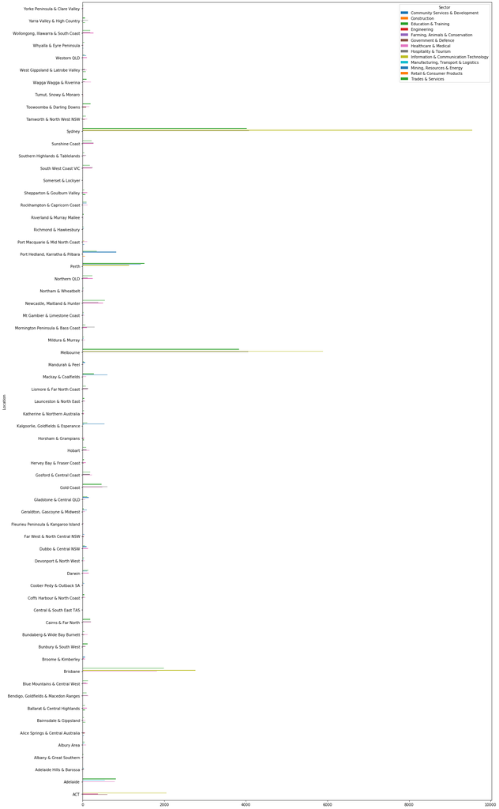

```python
top3_CitySectorDF['No of jobs'].unstack().plot.barh(figsize=(20,40))
```

### **City: Highest/Lowest Salary and Salary Range**

#### a) Highest/Lowest Salary Analysis:

```python
high_lowDF = jobDF.groupby('Location').agg({"LowestSalary":"min", "HighestSalary":"max"})
high_lowDF
```

| Location | LowestSalary | HighestSalary |
| --- | --- | --- |
| ACT | 0 | 999 |
| Adelaide | 0 | 999 |
| Adelaide Hills & Barossa | 0 | 999 |
| Albany & Great Southern | 0 | 999 |
| Albury Area | 0 | 999 |
| ... | ... | ... |
| Western QLD | 0 | 999 |
| Whyalla & Eyre Peninsula | 0 | 999 |
| Wollongong, Illawarra & South Coast | 0 | 999 |
| Yarra Valley & High Country | 0 | 999 |
| Yorke Peninsula & Clare Valley | 0 | 999 |

65 rows × 2 columns

```python
high_lowDF[high_lowDF['LowestSalary']!=0]
```

|  | LowestSalary | HighestSalary |
| --- | --- | --- |
| Location |  |  |

```python
high_lowDF[high_lowDF['HighestSalary']!=999]
```

| Location | LowestSalary | HighestSalary |
| --- | --- | --- |
| Central & South East TAS | 0 | 150 |
| Fleurieu Peninsula & Kangaroo Island | 0 | 150 |
| Riverland & Murray Mallee | 0 | 200 |

As can be seen from above result, all of the **min values** of the **LowestSalary** are 0s and most of **max value** of **HighestSalary** are 999s (except 3 values). So we will take the **mean** of those attributes for calculation.

```python
high_lowDF = jobDF.groupby('Location').agg("mean")
high_lowDF
```

| Location | LowestSalary | HighestSalary |
| --- | --- | --- |
| ACT | 86.174400 | 198.718240 |
| Adelaide | 57.991883 | 97.021494 |
| Adelaide Hills & Barossa | 41.191710 | 68.948187 |
| Albany & Great Southern | 56.600000 | 101.233333 |
| Albury Area | 51.201923 | 75.543269 |
| ... | ... | ... |
| Western QLD | 69.357977 | 134.128405 |
| Whyalla & Eyre Peninsula | 53.980100 | 86.000000 |
| Wollongong, Illawarra & South Coast | 55.829813 | 90.895594 |
| Yarra Valley & High Country | 44.168337 | 68.945892 |
| Yorke Peninsula & Clare Valley | 44.895833 | 77.791667 |

65 rows × 2 columns

```python
high_lowDF['SalaryRange'] = high_lowDF['HighestSalary'] - high_lowDF['LowestSalary']
```

```python
high_lowDF
```

| Location | LowestSalary | HighestSalary | SalaryRange |
| --- | --- | --- | --- |
| ACT | 86.174400 | 198.718240 | 112.543840 |
| Adelaide | 57.991883 | 97.021494 | 39.029611 |
| Adelaide Hills & Barossa | 41.191710 | 68.948187 | 27.756477 |
| Albany & Great Southern | 56.600000 | 101.233333 | 44.633333 |
| Albury Area | 51.201923 | 75.543269 | 24.341346 |
| ... | ... | ... | ... |
| Western QLD | 69.357977 | 134.128405 | 64.770428 |
| Whyalla & Eyre Peninsula | 53.980100 | 86.000000 | 32.019900 |
| Wollongong, Illawarra & South Coast | 55.829813 | 90.895594 | 35.065782 |
| Yarra Valley & High Country | 44.168337 | 68.945892 | 24.777555 |
| Yorke Peninsula & Clare Valley | 44.895833 | 77.791667 | 32.895833 |

65 rows × 3 columns

This below chart shows salary values with highest salary is sorted in descending order:

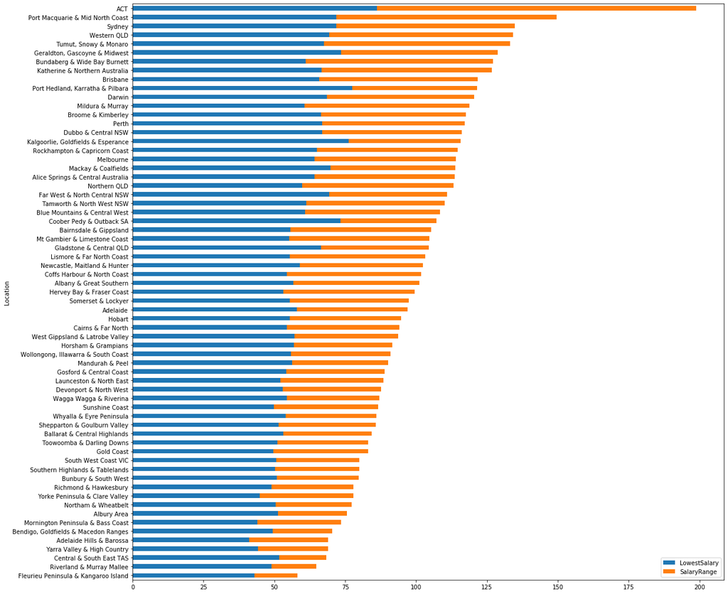

```python
high_sortedDF = high_lowDF.sort_values(by='HighestSalary')
high_sortedDF[['LowestSalary', 'SalaryRange']].plot(kind='barh', stacked=True, figsize=(18,18))
```

From the chart above:

- Top 5 cities having highest salary: ACT, Port Macquarie & Mid North Coast, Sydney, Western QLD and Tumut, Snowy & Monaro
- Top 5 cites have highest of lowest salary: ACT, Port Hedland, Karratha & Pilbara, Kalgoorlie, Goldfields & Esperance, Geraldton, Gascoyne & Midwest andCoober Pedy & Outback SA

In conclusion: ACT is the place that the employees are most well-paid.

#### b) Salary Range analysis

**Compare range_LowestSalary and range_HighestSalary:**

The range between the max value and min value of LowestSalary:

```python
range_LowestSalary = high_lowDF['LowestSalary'].max() - high_lowDF['LowestSalary'].min()
range_LowestSalary
```

```
44.98269015544042
```

```python
range_HighestSalary = high_lowDF['HighestSalary'].max() - high_lowDF['LowestSalary'].min()
range_HighestSalary
```

```
157.5265301554404
```

From 2 values above, the range_HighestSalary is bigger than the range_LowestSalary

**Observation about salary range in each city**:

```python
high_lowDF
```

| Location | LowestSalary | HighestSalary | SalaryRange |
| --- | --- | --- | --- |
| ACT | 86.174400 | 198.718240 | 112.543840 |
| Adelaide | 57.991883 | 97.021494 | 39.029611 |
| Adelaide Hills & Barossa | 41.191710 | 68.948187 | 27.756477 |
| Albany & Great Southern | 56.600000 | 101.233333 | 44.633333 |
| Albury Area | 51.201923 | 75.543269 | 24.341346 |
| ... | ... | ... | ... |
| Western QLD | 69.357977 | 134.128405 | 64.770428 |
| Whyalla & Eyre Peninsula | 53.980100 | 86.000000 | 32.019900 |
| Wollongong, Illawarra & South Coast | 55.829813 | 90.895594 | 35.065782 |
| Yarra Valley & High Country | 44.168337 | 68.945892 | 24.777555 |
| Yorke Peninsula & Clare Valley | 44.895833 | 77.791667 | 32.895833 |

65 rows × 3 columns

#### c) The pattern of posting in each city

```python
from datetime import datetime
```

```python
city_patternDF = jobDF[['Location', 'Date', 'Title']]
city_patternDF = city_patternDF.fillna("unknown")
city_patternDF
```

|  | Location | Date | Title |
| --- | --- | --- | --- |
| 0 | Sydney | 2018-10-07 | Casual Stock Replenisher |
| 1 | Richmond & Hawkesbury | 2018-10-07 | Casual Stock Replenisher |
| 2 | Brisbane | 2018-10-07 | RETAIL SALES SUPERSTARS and STYLISTS Wanted - ... |
| 3 | Gosford & Central Coast | 2018-10-07 | Team member - Belrose |
| 4 | Sydney | 2018-10-07 | Business Banking Contact Centre Specialist, Ni... |
| ... | ... | ... | ... |
| 318472 | unknown | 2019-03-13 | Program Manager - Trade Reporting |
| 318473 | unknown | 2019-03-13 | Web Content Writer - June 2019 contract |
| 318474 | unknown | 2019-03-12 | Brand Director - Global Premium Brand |
| 318475 | unknown | 2019-03-08 | Head of Financial Planning, Reporting & Strategy |
| 318476 | unknown | 2019-03-13 | Head of Operations - EOI |

318477 rows × 3 columns

```python
city_patternDF['Date'] = pd.to_datetime(city_patternDF['Date'])
city_patternDF['Date'] = city_patternDF['Date'].map(lambda x:  x.strftime('%Y-%m'))
city_patternDF
```

|  | Location | Date | Title |
| --- | --- | --- | --- |
| 0 | Sydney | 2018-10 | Casual Stock Replenisher |
| 1 | Richmond & Hawkesbury | 2018-10 | Casual Stock Replenisher |
| 2 | Brisbane | 2018-10 | RETAIL SALES SUPERSTARS and STYLISTS Wanted - ... |
| 3 | Gosford & Central Coast | 2018-10 | Team member - Belrose |
| 4 | Sydney | 2018-10 | Business Banking Contact Centre Specialist, Ni... |
| ... | ... | ... | ... |
| 318472 | unknown | 2019-03 | Program Manager - Trade Reporting |
| 318473 | unknown | 2019-03 | Web Content Writer - June 2019 contract |
| 318474 | unknown | 2019-03 | Brand Director - Global Premium Brand |
| 318475 | unknown | 2019-03 | Head of Financial Planning, Reporting & Strategy |
| 318476 | unknown | 2019-03 | Head of Operations - EOI |

318477 rows × 3 columns

```python
# JobSector = df_Job.groupby(['Classification', 'Date'])['Title'].count()
city_pattern_job =  city_patternDF.groupby(['Location','Date'])['Title'].count()
city_pattern_job
```

```
Location                        Date
ACT                             2018-10     3579
                                2018-11     1427
                                2018-12     1244
Adelaide                        2018-10     3702
                                2018-11     1434
                                           ...
Yorke Peninsula & Clare Valley  2018-12       17
unknown                         2018-12    29167
                                2019-01    69676
                                2019-02    22003
                                2019-03      402
Name: Title, Length: 199, dtype: int64
```

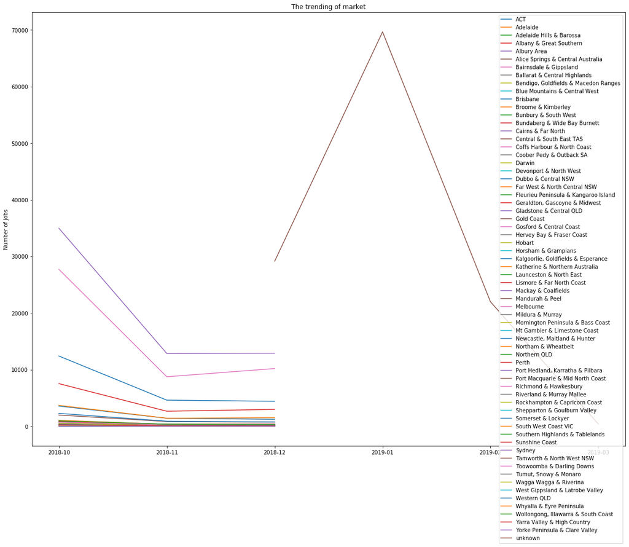

```python
plt.figure(figsize=(20,15))
for location in city_pattern_job.index.get_level_values(0).unique():
    plt.plot(city_pattern_job[location], label=location)
plt.title("The trending of market")
plt.ylabel("Number of jobs")

plt.legend()
plt.show()
```

**Evaluation:**  
Because the the value of data in 2019 has no detailed location, so this evaluation has 2 parts: in 2018 and 2019  
**- 2018**: There are 3 kinds of trend:

1. The number of jobs fall dramatically from 2018-10 to 2018-11 then began to increase slightly in 2018-12.
2. The number of jobs fall from 2018-10 to 2018-11 then kept falling in 2018-12 but more slightly.
3. The number of jobs fall from 2018-10 to 2018-11 then kept stable in 2018-12

**- 2019**: The number of jobs increased sharply from 2018-12 to 2019-01 then decreased until 2019-03

## 3) Study the market by sector

### Sectors that keep the highest market share:

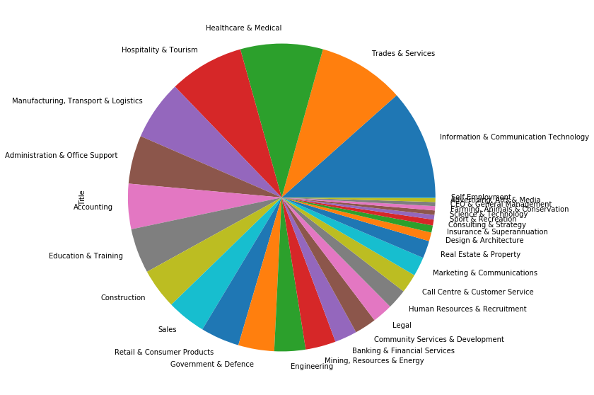

```python
MarketSectors = df.groupby('Classification')['Title'].count().sort_values(ascending=False)
plot = MarketSectors.plot.pie(y='', figsize=(10, 10))
```

- Base on the chart above, **Information and Communication Technology**, **Trades & Services**, **Healthcare & Medical**, **Hospitability & Tourism** are sectors keeping the highest market share

### In each sector, which sub-sectors are the main spotlights?

```python
Spotlights = job.groupby(['Sector', 'SubSector'])['SubSector'].count()

#Spotlights = job.groupby(['Sector', 'SubSector']).agg({'SubSector':'count'})
Spotlights
```

```
Sector             SubSector
                                                         121248
Accounting         Accounts Officers/Clerks                 929
                   Accounts Payable                         531
                   Accounts Receivable/Credit Control       612
                   Analysis & Reporting                     530
                                                          ...
Trades & Services  Printing & Publishing Services           154
                   Security Services                        483
                   Tailors & Dressmakers                     35
                   Technicians                             1161
                   Welders & Boilermakers                  1155
Name: SubSector, Length: 397, dtype: int64
```

```python
#create 3 array to save element
sectorArr = ['Sector']
subsector = ['SubSector']
value = ['Value']

#get max of each sector and save to the corresponding array
for sector in Spotlights.index.get_level_values(0).unique():
    if (sector == ' '):
        continue
    max = Spotlights[sector].max()
    sectorArr.append(sector)
    subsector.append(Spotlights[sector][Spotlights[sector] == max].index[0])
    value.append(max)

#create new series to contain result
result = pd.Series(value, index = [sectorArr, subsector])
result
```

```
Sector                                  SubSector                                     Value
                                                                                     121248
Accounting                              Financial Accounting & Reporting               1183
Administration & Office Support         Administrative Assistants                      4572
Advertising, Arts & Media               Agency Account Management                       147
Banking & Financial Services            Compliance & Risk                               723
CEO & General Management                General/Business Unit Manager                   520
Call Centre & Customer Service          Customer Service - Call Centre                 2087
Community Services & Development        Aged & Disability Support                      1966
Construction                            Project Management                             1930
Consulting & Strategy                   Management & Change Consulting                  344
Design & Architecture                   Architecture                                    436
Education & Training                    Childcare & Outside School Hours Care          2383
Engineering                             Civil/Structural Engineering                   1698
Farming, Animals & Conservation         Horticulture                                    171
Government & Defence                    Government - State                             3701
Healthcare & Medical                    Nursing - Aged Care                            2130
Hospitality & Tourism                   Chefs/Cooks                                    4600
Human Resources & Recruitment           Consulting & Generalist HR                     1135
Information & Communication Technology  Developers/Programmers                         4211
Insurance & Superannuation              Claims                                          536
Legal                                   Legal Secretaries                               735
Manufacturing, Transport & Logistics    Warehousing, Storage & Distribution            3636
Marketing & Communications              Marketing Communications                        748
Mining, Resources & Energy              Mining - Engineering & Maintenance             2174
Real Estate & Property                  Residential Leasing & Property Management      1166
Retail & Consumer Products              Retail Assistants                              3902
Sales                                   Sales Representatives/Consultants              3370
Science & Technology                    Environmental, Earth & Geosciences              197
Self Employment                         Self Employment                                  93
Sport & Recreation                      Fitness & Personal Training                     406
Trades & Services                       Automotive Trades                              3262
dtype: object
```

### What is the salary range for each sector/sub-sector? Can you compare salary range between sectors/subsectors?

```python
#create new dataframe to extract data
sal = job[['Sector', 'SubSector', 'LowestSalary', 'HighestSalary', 'Range']]
#group by Sector and SubSector
sal.groupby(['Sector', 'SubSector']).mean()
```

| Sector | SubSector | LowestSalary | HighestSalary | Range |
| --- | --- | --- | --- | --- |
|  |  | 65.399512 | 105.199418 | 39.799906 |
| Accounting | Accounts Officers/Clerks | 44.090420 | 66.009688 | 21.919268 |
|  | Accounts Payable | 42.241055 | 61.745763 | 19.504708 |
|  | Accounts Receivable/Credit Control | 44.019608 | 60.374183 | 16.354575 |
|  | Analysis & Reporting | 83.490566 | 130.594340 | 47.103774 |
| ... | ... | ... | ... | ... |
| Trades & Services | Printing & Publishing Services | 35.844156 | 50.259740 | 14.415584 |
|  | Security Services | 40.289855 | 57.803313 | 17.513458 |
|  | Tailors & Dressmakers | 32.000000 | 45.714286 | 13.714286 |
|  | Technicians | 45.555556 | 61.679587 | 16.124031 |
|  | Welders & Boilermakers | 48.017316 | 64.735931 | 16.718615 |

397 rows × 3 columns

```python
#group by SubSector
sal.groupby('SubSector').mean()
```

| SubSector | LowestSalary | HighestSalary | Range |
| --- | --- | --- | --- |
|  | 65.399512 | 105.199418 | 39.799906 |
| Account & Relationship Management | 69.433155 | 102.520856 | 33.087701 |
| Accounts Officers/Clerks | 44.090420 | 66.009688 | 21.919268 |
| Accounts Payable | 42.241055 | 61.745763 | 19.504708 |
| Accounts Receivable/Credit Control | 44.019608 | 60.374183 | 16.354575 |
| ... | ... | ... | ... |
| Web Development & Production | 89.004425 | 165.643805 | 76.639381 |
| Welders & Boilermakers | 48.017316 | 64.735931 | 16.718615 |
| Winery & Viticulture | 58.333333 | 105.633333 | 47.300000 |
| Workers' Compensation | 59.137931 | 77.816092 | 18.678161 |
| Workplace Training & Assessment | 66.620209 | 92.083624 | 25.463415 |

339 rows × 3 columns

```python
#group by Sector
SalSector = sal.groupby('Sector').mean()
SalSector
```

| Sector | LowestSalary | HighestSalary | Range |
| --- | --- | --- | --- |
|  | 65.399512 | 105.199418 | 39.799906 |
| Accounting | 67.137062 | 108.139838 | 41.002775 |
| Administration & Office Support | 40.057884 | 57.147705 | 17.089820 |
| Advertising, Arts & Media | 56.062425 | 84.644658 | 28.582233 |
| Banking & Financial Services | 78.508526 | 143.533779 | 65.025254 |
| CEO & General Management | 126.741706 | 384.127962 | 257.386256 |
| Call Centre & Customer Service | 39.790985 | 57.398136 | 17.607152 |
| Community Services & Development | 47.977703 | 68.732219 | 20.754515 |
| Construction | 89.939083 | 163.196011 | 73.256928 |
| Consulting & Strategy | 101.948590 | 213.184909 | 111.236318 |
| Design & Architecture | 67.355052 | 111.046383 | 43.691331 |
| Education & Training | 59.173491 | 86.236530 | 27.063039 |
| Engineering | 90.346857 | 152.014710 | 61.667854 |
| Farming, Animals & Conservation | 46.972789 | 68.621315 | 21.648526 |
| Government & Defence | 75.943840 | 131.460701 | 55.516861 |
| Healthcare & Medical | 72.934738 | 162.015920 | 89.081182 |
| Hospitality & Tourism | 33.081879 | 47.406558 | 14.324680 |
| Human Resources & Recruitment | 69.734556 | 109.499276 | 39.764720 |
| Information & Communication Technology | 108.765573 | 256.279084 | 147.513511 |
| Insurance & Superannuation | 67.876526 | 105.000000 | 37.123474 |
| Legal | 87.481709 | 156.894501 | 69.412792 |
| Manufacturing, Transport & Logistics | 46.964286 | 70.607708 | 23.643423 |
| Marketing & Communications | 67.825101 | 101.468750 | 33.643649 |
| Mining, Resources & Energy | 92.293257 | 164.978849 | 72.685592 |
| Real Estate & Property | 57.927504 | 100.794687 | 42.867183 |
| Retail & Consumer Products | 36.608631 | 53.476806 | 16.868176 |
| Sales | 63.446237 | 101.293263 | 37.847025 |
| Science & Technology | 74.320442 | 127.893923 | 53.573481 |
| Self Employment | 70.967742 | 111.806452 | 40.838710 |
| Sport & Recreation | 45.203252 | 73.359756 | 28.156504 |
| Trades & Services | 44.829217 | 61.948821 | 17.119604 |

### Compare salary range between sectors/subsectors:

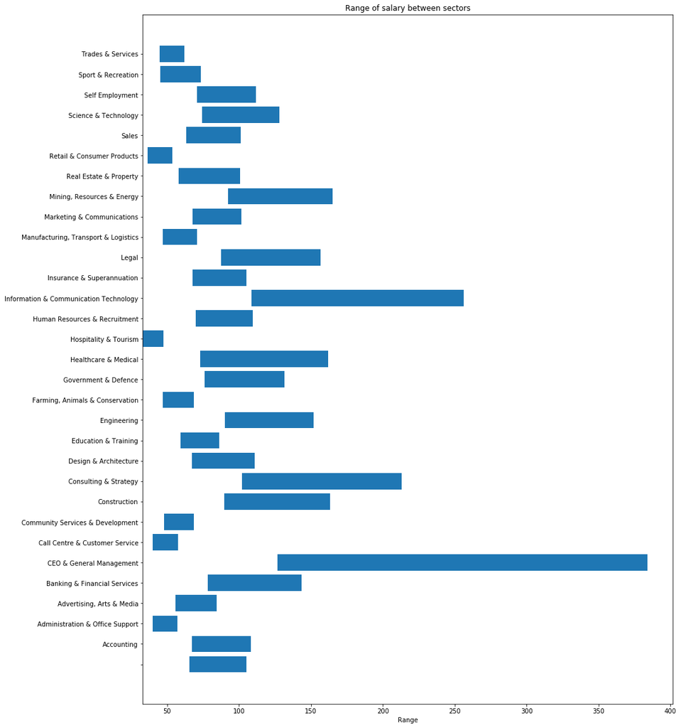

```python
index_labels = SalSector.index
index = np.arange(len(index_labels))
right_edge = SalSector['Range']
left_edge = SalSector['LowestSalary']
plt.figure(figsize=(15,20))
plt.barh(index, right_edge, left=left_edge)
plt.yticks(index, index_labels)
plt.xlabel('Range')
plt.title('Range of salary between sectors')
```